# Notes on GGplot2

Rupert

23 February 2019

## The Grammar

### layers - points lines etc

### scales - mapping to the graphical output

### coordinates - perspective (the grid)

### faceting - visual drill down (subsetting) into the data (pivot table like)

### themes - details of the disply (fonts)

## What you actually need 80% of the time

### Asthetic (aes) mappings for the visualisation - passenger information mapping to y axis

### layers - at least one to render the data (ggplot geom function) ege a simple scatter plot

```r
#install.packages("ggplot2")
#install.packages("dplyr")
#library(dplyr)
library(ggplot2)
```

### Load Data

Factors are going to be important for ggplot2’s calculations (https://www.stat.berkeley.edu/~s133/factors.html)

```r
titanic <- read.csv("titanic.csv", stringsAsFactors = FALSE)
View(titanic)
```

```r
titanic$Pclass <- as.factor(titanic$Pclass)
titanic$Survived <- as.factor(titanic$Survived)
titanic$Sex <- as.factor(titanic$Sex)
titanic$Embarked <- as.factor(titanic$Embarked)

#converted to factors because these are catagories and not used for calculation - ggplot2 is smart and will use these for colour coding etc
```

# plotting

## First question - What was the survival rate?

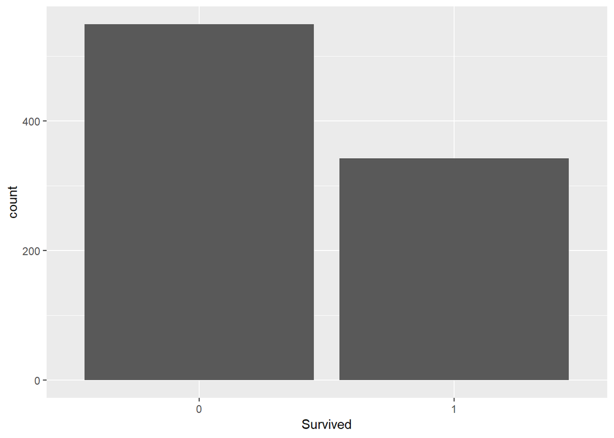

```r
#
# We'll start our visual analysis of the data focusing on questions
# related to survival rates. Specifically, these questions will use
# the factor (i.e., categorical) variables in the data. Factor data
# is very common in the business context and ggplot2 offers many
# powerful features for visualizing factor data.
#


#
# First question - What was the survival rate?
#
# As Survived is a factor (i.e., categorical) variable, a bar chart
# is a great visualization to use.
#

ggplot(titanic, aes(x = Survived)) +
  geom_bar()
```

```r
# If you really want percentages.
prop.table(table(titanic$Survived))
```

```
##
##         0         1
## 0.6161616 0.3838384
```

## Nicer graphics - Themes

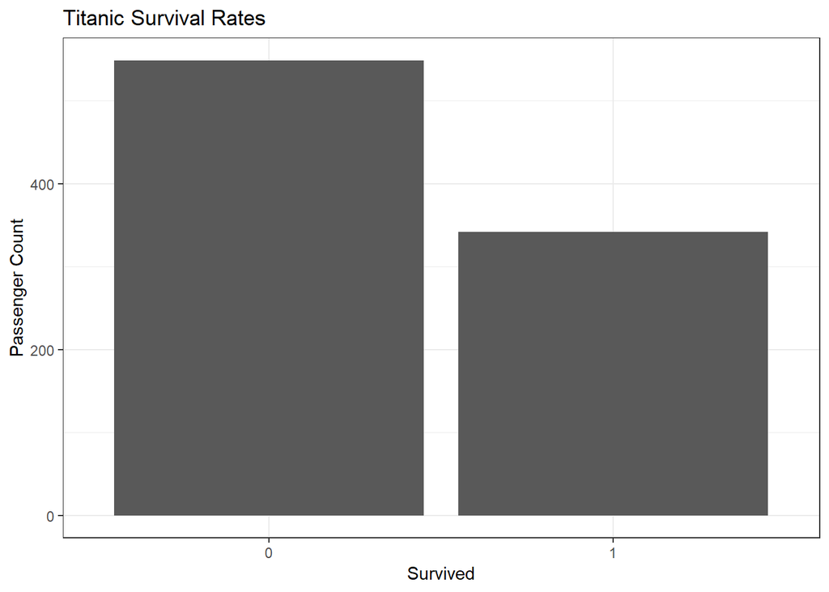

```r
# Add some customization for labels and theme.
ggplot(titanic, aes(x = Survived)) +
  theme_bw() +
  geom_bar() +
  labs(y = "Passenger Count",
       title = "Titanic Survival Rates")
```

## Second question - What was the survival rate by gender?

We can use color to look at two aspects (i.e., dimensions) of the data simultaneously.

# using fill - filled proportional to ‘survived’

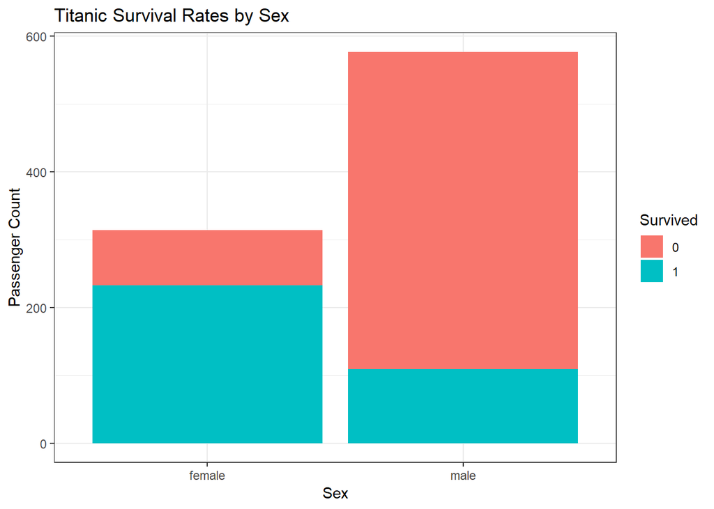

```r
ggplot(titanic, aes(x = Sex, fill = Survived)) +
  theme_bw() +
  geom_bar() +
  labs(y = "Passenger Count",
       title = "Titanic Survival Rates by Sex")
```

## Third question - What was the survival rate by class of ticket?

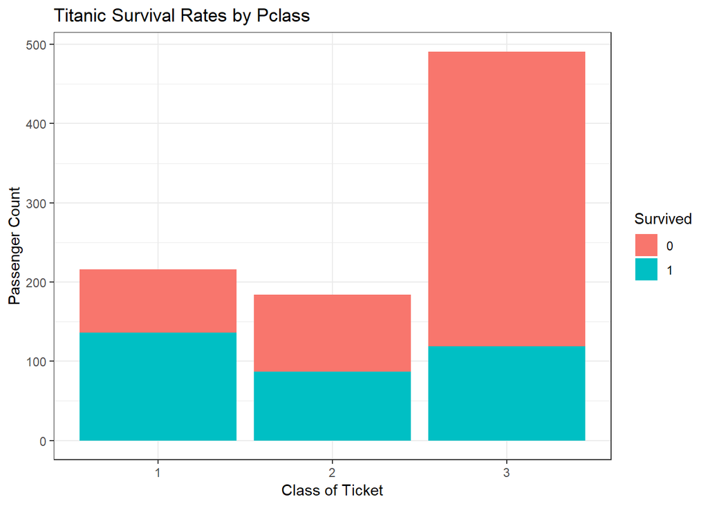

```r
ggplot(titanic, aes(x = Pclass, fill = Survived)) +
  theme_bw() +
  geom_bar() +
  labs(y = "Passenger Count",
       x = "Class of Ticket",
       title = "Titanic Survival Rates by Pclass")
```

# facetting

## Fourth question - What was the survival rate by class of ticket and gender?

We can leverage facets to further segment the data and enable “visual drill-down” into the data.

## ~ (surogate of by)

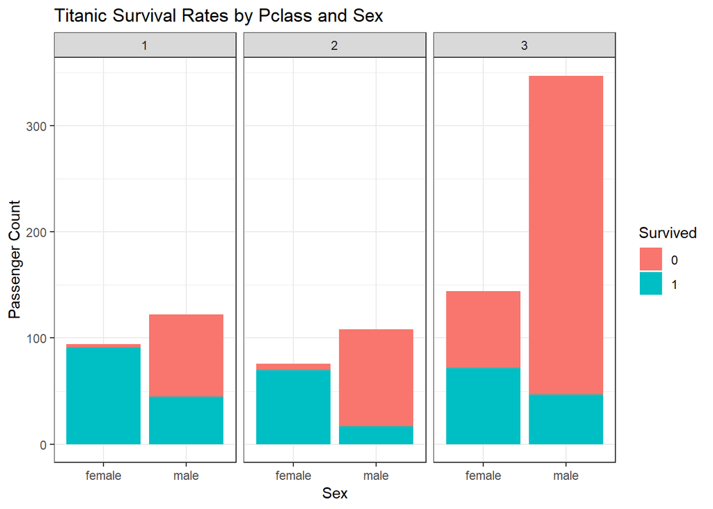

```r
#
ggplot(titanic, aes(x = Sex, fill = Survived)) +
  theme_bw() +
  facet_wrap(~ Pclass) +
  geom_bar() +
  labs(y = "Passenger Count",
       title = "Titanic Survival Rates by Pclass and Sex")
```

# Continuous Data

Next, we’ll move on to visualizing continuous (i.e., numeric) data using ggplot2. We’ll explore visualizations of single numeric variables (i.e., columns) and also illustrate how ggplot2 enables visual drill-down on numeric data.

## Fifth Question - What is the distribution of passenger ages?

The histogram is a staple of visualizing numeric data as it very powerfully communicates the distrubtion of a variable (i.e., column).

177 values do not have data

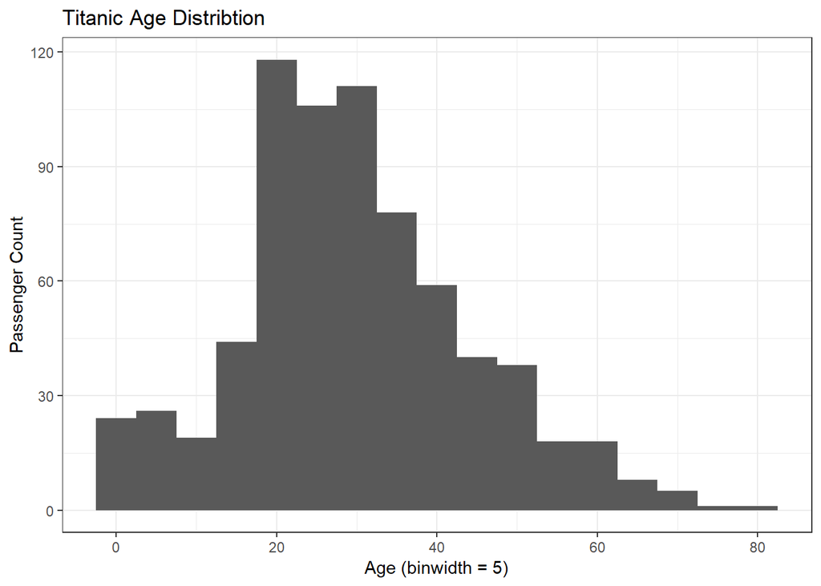

```r
ggplot(titanic, aes(x = Age)) +
  theme_bw() +
  geom_histogram(binwidth = 5) +
  labs(y = "Passenger Count",
       x = "Age (binwidth = 5)",
       title = "Titanic Age Distribtion")
```

## Sixth Question - What are the survival rates by age?

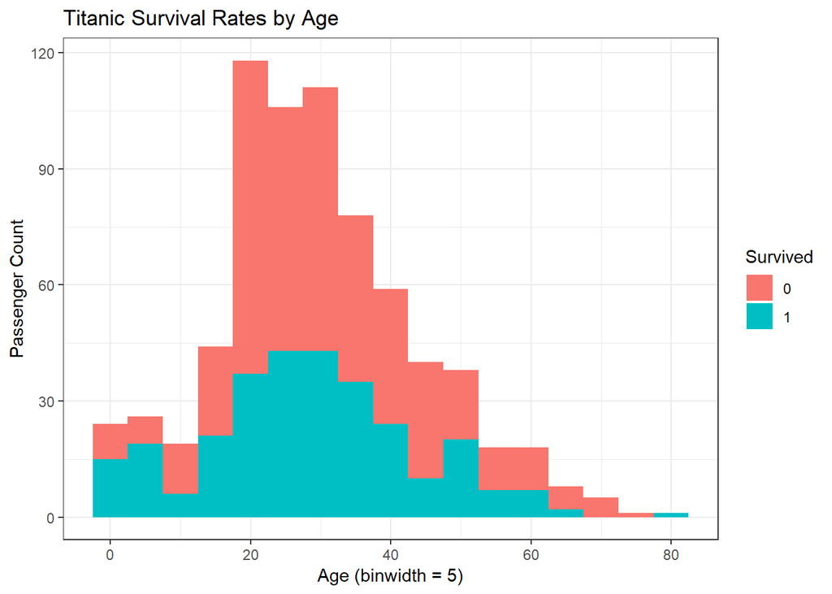

```r
ggplot(titanic, aes(x = Age, fill = Survived)) +
  theme_bw() +
  geom_histogram(binwidth = 5) +
  labs(y = "Passenger Count",
       x = "Age (binwidth = 5)",
       title = "Titanic Survival Rates by Age")
```

## Another great visualization for this question is the box-and-whisker plot.

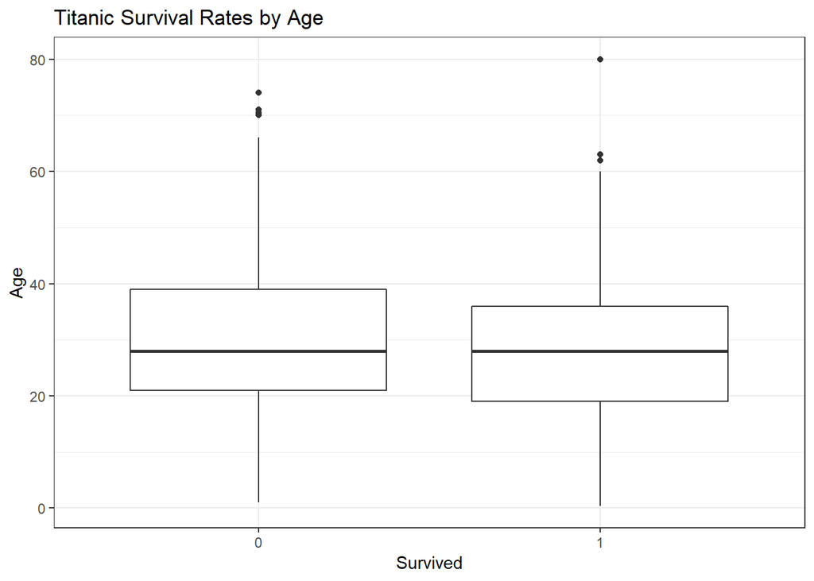

```r
ggplot(titanic, aes(x = Survived, y = Age)) +
  theme_bw() +
  geom_boxplot() +
  labs(y = "Age",
       x = "Survived",
       title = "Titanic Survival Rates by Age")
```